# Exploring An Interesting Dataset

Leighton Pritchard

2021 Presentation

# 1 Introduction

- We look at an example dataset from a clinical study
  - The study aimed to identify key risk factors for developing Graft-versus-Host-Disease (GvHD)
  - The *response variable* is `gvhd` (development or non-development of GvHD)
  - The study examined the influence of six *explanatory variables*
- Scatterplots are useful to compare two continuous numerical variables
- Boxplots are useful to compare the numerical outputs for two categorical explanatory variables
- Pairs plots give a quick visual overview of the data

# 2 The Dataset

This notebook explores a dataset representing a study of bone marrow transplantation in leukaemia patients, published in:

> Bagot, M., Mary, J.‐Y., Heslan, M., Kuentz, M., Cordonnier, C., Vernant, J.‐P., Dubertret, L. and Levy, J.‐P. (1988), The mixed epidermal cell lymphocyte‐reaction is the most predictive factor of acute graft‐versus‐host disease in bone marrow graft recipients.* British Journal of Haematology*, 70: 403-409. https://doi.org/10.1111/j.1365-2141.1988.tb02508.x

The data describes outcomes for 37 patients who received non-depleted allogenic bone marrow transplants from HLA-identical sibling donors, as treatment for their disease. Unfortunately, Graft-versus-Host-Disease (GvHD) is a significant cause of morbidity and mortality in such patients. The published study aimed to identify key risk factors for developing GvHD.

- `patient`: a unique index number denoting an individual patient; this is not strictly a variable, but an identifier or *index*
- `recipient_m_f`: coded `0` for male; `1` for female
- `recipient_age`: the age of the recipient in years (numerical, continuous)
- `donor_m_f_preg`: coded `0` for male; `1` for female (never been pregnant); `2` for female (at least one pregnancy) (categorical, not ordered)
- `donor_age`: the age of the donor in years (numerical, continuous)
- `type`: coded `1` for acute myeloid leukaemia; `2` for acute lymphocytic leukaemia; `3` for chronic myeloid leukaemia (categorical, not ordered)
- `index`: a ratio of two clinical measurements: MECLR/MLR (the details of this are not important for us) (numerical, continuous)
- `gvhd`: coded `1` if the patient developed GvHD, `0` if they did not (categorical, not ordered)
- `time`: the number of days until the clinical outcome (death or survival) was measured (numerical, discrete)

|  | patient | time | recipient_m_f | recipient_age | donor_age | type | donor_m_f_preg | index | gvhd |
| --- | --- | --- | --- | --- | --- | --- | --- | --- | --- |
| 1 | 1 | 95 | 0 | 27 | 23 | 2 | 1 | 0.27 | 0 |
| 2 | 2 | 1385 | 0 | 13 | 18 | 2 | 1 | 0.31 | 0 |
| 3 | 3 | 465 | 0 | 19 | 19 | 1 | 1 | 0.39 | 0 |
| 4 | 4 | 810 | 0 | 21 | 22 | 2 | 1 | 0.48 | 0 |
| 5 | 5 | 1497 | 0 | 28 | 38 | 2 | 0 | 0.49 | 0 |
| 6 | 6 | 1181 | 1 | 22 | 20 | 2 | 1 | 0.5 | 0 |
| 7 | 7 | 993 | 0 | 19 | 19 | 2 | 1 | 0.81 | 0 |
| 8 | 8 | 138 | 0 | 20 | 23 | 2 | 1 | 0.82 | 0 |
| 9 | 9 | 266 | 1 | 33 | 36 | 1 | 0 | 0.86 | 0 |
| 10 | 10 | 579 | 1 | 18 | 19 | 1 | 0 | 0.92 | 0 |

[output cut: 27 more lines]

The *response variable* is `gvhd`, representing the development of GvHD.

This dataset can inform both *understanding* and *prediction* questions.

# 3 Visualisation

The first step in exploring any dataset is often to visualise it. Graphing a scatterplot for two variables can show us whether there appears to be a relationship between their values. For example, graphing `recipient_age` against `donor_age` shows a clear relationship where donor age increases with recipient age.

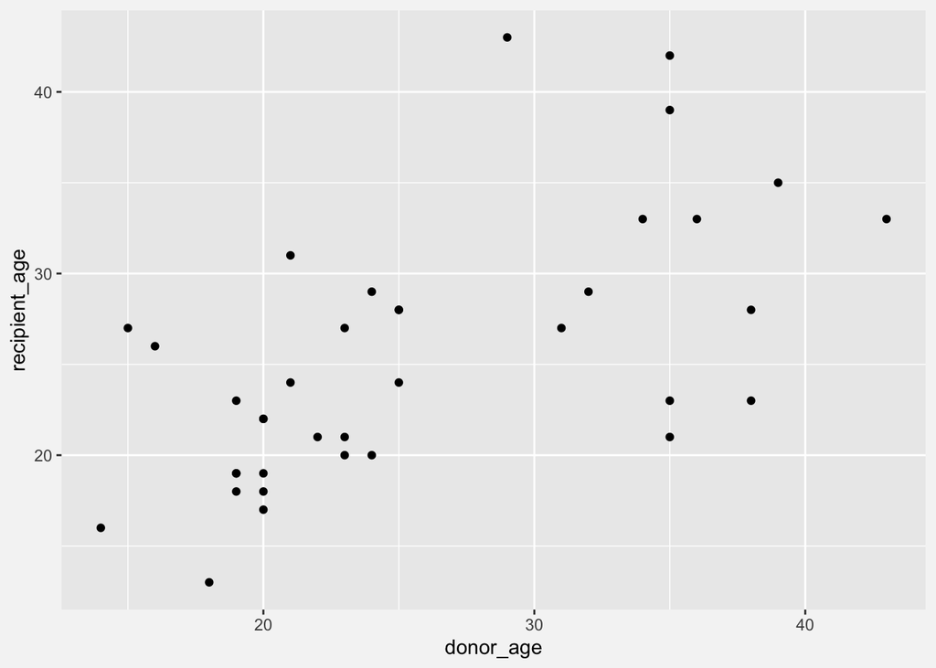

Figure 3.1: Scatter plot of recipient age against donor age.

This is probably to be expected, as the donor and recipient are matched siblings, and are likely to be of similar age.

### 3.0.1 Scatterplots are not always useful for non-numerical data

Scatterplots can be helpful when visualising continuous (and, sometimes, discrete) numerical data. The plot of recipient age against donor age above showed us an interesting relationship. However, we this study is interested in a *categorical* response variable, that only takes values `0` or `1`.

A scatter plot of this response variable `gvhd` (which is a binary categorical variable) against recipient age is not so useful:

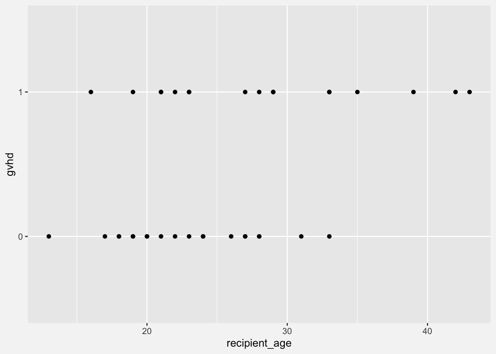

Figure 3.2: Scatter plot of GvHD outcome against recipient age.

It is generally the case for categorical data that scatterplots do not show relationships well. However you might be able to tell from this graph that there is a slight tendency for younger recipients (under 35) not to develop GvHD.

### 3.0.2 Scatterplots may overplot datapoints

A potential disadvantage of scatterplots is that two or more datapoints with the same or similar values may be plotted in such a way that they appear to be only a single point. In figure 2, several individuals with the same age are found in each of the `gvhd` outcomes, and their corresponding points are overplotted. We cannot tell whether there are many people, or only one, associated with each of the points in the graph.

As a result, visual interpretations of plots can sometimes be misleading, due to the false underrepresentation of datapoints that have similar values.

## 3.1 Comparing categorical outcomes

We saw above that scatterplots are not always very useful for visualising the relationship between a *categorical* response variable and numerical *explanatory* variables.

Other visualisation types can represent this data in a more helpful way by representing the data for each outcome category as a separate distribution of datapoints. This then allows for comparison of the distributions to see if there is a difference in the relationship of the explanatory variable with each of the outcomes.

The distribution summarises all the datapoints, and helps us overcome the overplotting problem described above.

### 3.1.1 Boxplots

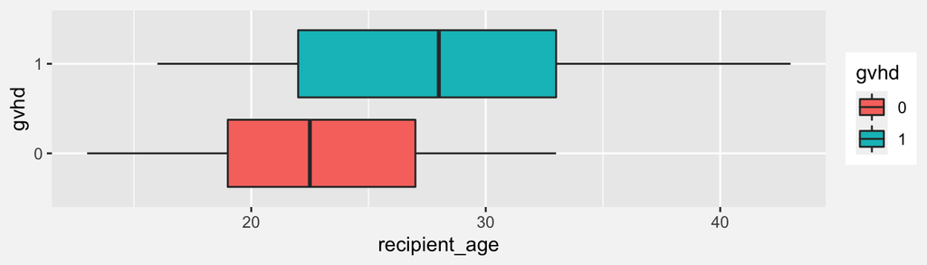

Figure 3.3: Boxplot of GvHD outcome against recipient age.

It is much clearer from this boxplot than it was from the scatterplot that there might be some relationship between GvHD and recipient age.

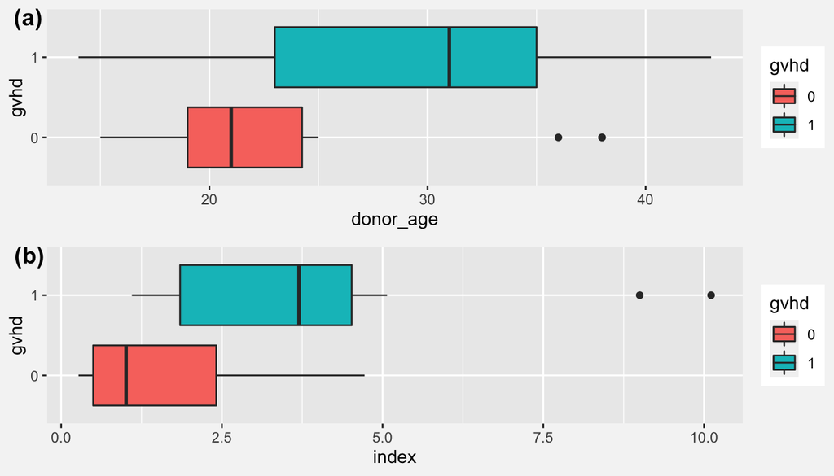

Figure 3.4: Boxplot of GvHD outcome against (a) donor age (b) MECLR/MLR index.

We can see from the boxplots in figure 3.4 representation that GvHD does appear to have depend in some way on the explanatory variables of donor and recipient age, and MECLR/MLR index.

## 3.2 Pairs plot

The `R` language was created specifically to work with data, and can treat numerical and categorical data appropriately. When we load in a dataset, we can specify what type of data is contained in each measured variable. This information can then be used by statistical packages to ensure we get an appropriate graphical output.

As an example, the `ggpairs` function from `GGally` generates scatterplots, boxplots, histograms, density plots and correlations, as appropriate, in the *pairs plot* below. It automatically identifies the type of data in each variable, and chooses the appropriate mode of visualisation for summarising and comparing the data from each pair of variables.

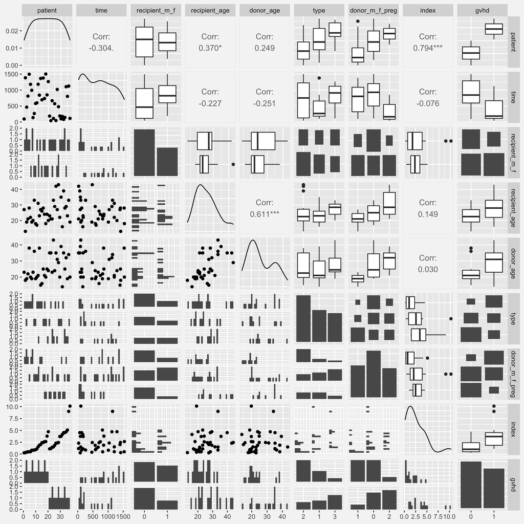

Figure 3.5: Pairs plot of `gvhd` data, providing an overview of relationships between variables.

This gives us a rich visual overview of the relationships in our dataset.

As a first assessment, we can look at each of the plots in the `gvhd` column of figure 3.5 and look to see whether there is a visual difference between distributions of the categories `0` (no GvHD) and `1` (GvHD development) for each of the explanatory variables.

1. Which explanatory variables appear to have some assocation with a difference in GvHD outcome?
2. For each of those variables, do you think the apparent association is biologically meaningful?

# 4 `R` code used in this notebook

**Click to toggle `R` code for loading data**

To load the dataset, we use `read_delim()` from the `readr` package. We specify the “tab” delimiter (`\t`) because each column in the data file is separated by this character. We define useful column names, and tell `R` what the data type is for each column in the `col_types` string:

- `i`: integer (numerical)
- `f`: factor (categorical)
- `d`: double (numerical, continuous)

```r
gvhd = read_delim("../assets/data/gvhd.dat", delim="\t",
                  col_names = c("patient", "time", "recipient_m_f", "recipient_age",
                                "donor_age", "type", "donor_m_f_preg", "index", "gvhd"),
                  col_types="iifiiffdf",
                  skip=1)
```

**Click to toggle `R` code for Figure 3.1**

The `R` code below plots `recipient_age` against `donor_age` in a scatterplot.

```r
p = ggplot(gvhd, aes(x=donor_age, y=recipient_age))           # create plot with gvhd data
p = p + geom_point()                                          # add scatterplot
p = p + theme(plot.background = element_rect(fill = figbg,    # colour plot background
                                             color = figbg))
p                                                             # show plot
```

**Click to toggle `R` code for Figure 3.2**

The code below plots `gvhd` outcome against `recipient_age` as a scatterplot.

```r
p = ggplot(gvhd, aes(x=recipient_age, y=gvhd))                # create plot with gvhd data
p = p + geom_point()                                          # add scatterplot
p = p + theme(plot.background = element_rect(fill = figbg,    # colour plot background
                                             color = figbg))
p                                                             # show plot
```

**Click to toggle `R` code for Figure 3.3**

In this figure, we show a boxplot relating the *response variable* `gvhd` to `recipient_age`. Note that, to get the horizontal boxplot, we can’t just swap `x` and `y` in the `ggplot()` function, but we must use `coord_flip()` to flip horozontal and vertical for the figure as a whole.

```r
p = ggplot(gvhd, aes(y=recipient_age, x=gvhd,                  # set up plot with gvhd data
                     group=gvhd, fill=gvhd))
p = p + coord_flip()                                           # flip figure x and y
p = p + geom_boxplot()                                         # add boxplot
p = p + theme(plot.background = element_rect(fill = figbg,     # change figure background
                                             color = figbg))
p                                                              # show plot
```

**Click to toggle `R` code for Figure 3.4**

Here, we create boxplots as in figure 3.3, but combine them into a single figure (with `(a)` and `(b)` labels) using the `ggarrange()` function that comes from the `ggpubr` package.

```r
p1 = ggplot(gvhd, aes(y=donor_age, x=gvhd,                     # set up first plot for donor_age
                      group=gvhd, fill=gvhd))
p1 = p1 + coord_flip()                                         # flip figure x and y
p1 = p1 + geom_boxplot()                                       # add boxplot
p1 = p1 + theme(plot.background = element_rect(fill = figbg,   # change figure background
                                               color = figbg))

p2 = ggplot(gvhd, aes(y=index, x=gvhd,                         # set up plot 2 for index
                      group=gvhd, fill=gvhd))
p2 = p2 + coord_flip()                                         # flip figure x and y
p2 = p2 + geom_boxplot()                                       # add boxplot
p2 = p2 + theme(plot.background = element_rect(fill = figbg,   # change figure background
                                               color = figbg))

ggarrange(p1, p2, labels=c("(a)", "(b)"),                      # combine boxplots into single
          ncol=1, nrow=2)                                      # figure with labels (a) and (b)
```

**Click to toggle `R` code for Figure 3.5**

This code uses the `GGally` package to render a *pairs plot* comparing each variable in the `gvhd` dataset, using the `ggpairs()` function.

```r
p = ggpairs(gvhd)                                             # create pairs plot for all gvhd data
p = p + theme(plot.background = element_rect(fill = figbg,    # colour background
                                             color = figbg))
p                                                             # show plot
```